# Course Project - Practical Machine Learning

Bruno Paes Leão

July 16, 2015

# Background

Using devices such as Jawbone Up, Nike FuelBand, and Fitbit it is now possible to collect a large amount of data about personal activity relatively inexpensively. These type of devices are part of the quantified self movement - a group of enthusiasts who take measurements about themselves regularly to improve their health, to find patterns in their behavior, or because they are tech geeks. One thing that people regularly do is quantify how much of a particular activity they do, but they rarely quantify how well they do it.

The goal of this project is to use sensor data to identify how well someone is performing barbell lifts. Data from sensors on the belt, forearm, arm, and dumbbell of 6 participants is employed. They were asked to perform barbell lifts correctly and incorrectly in 5 different ways. More information is available from the website here: http://groupware.les.inf.puc-rio.br/har (see the section on the Weight Lifting Exercise Dataset).

This is an assignment of Johns Hopkins University [Practical Machine Learning course](https://class.coursera.org/predmachlearn-030/) at Coursera.

# Analysis

## Datasets

Two datasets were employed. The [training dataset](https://d396qusza40orc.cloudfront.net/predmachlearn/pml-training.csv) contains 19622 samples and 160 variables. The variable “classe” is the label, containing 5 levels, A to E, corresponding to each different class of correct/incorrect exercise execution. The [testing dataset](https://d396qusza40orc.cloudfront.net/predmachlearn/pml-testing.csv) contains 20 unlabeled samples. The final goal of this assignment is to build a classification model to estimate the labels for this test dataset.

## Data Analysis

The training dataset was partitioning to use 80% of the dataset for training the model, leaving 20% of the samples as hold-out for validation. Near zero variance predictiors and variables containing only NA readings were eliminated. This yielded a final set of 52 variables to be used as predictors in the models.

Exploratory data analysis was performed by plotting the features as a function of the label for each sensor location. Plots can be found below.

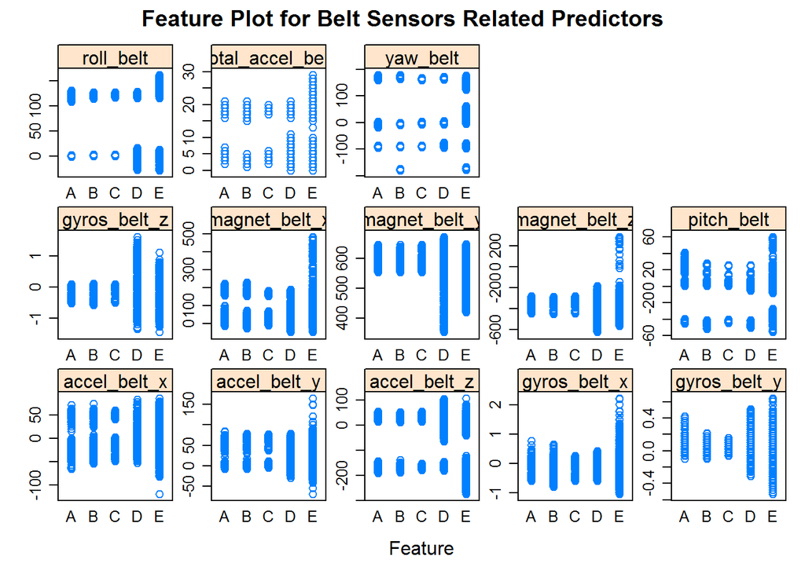

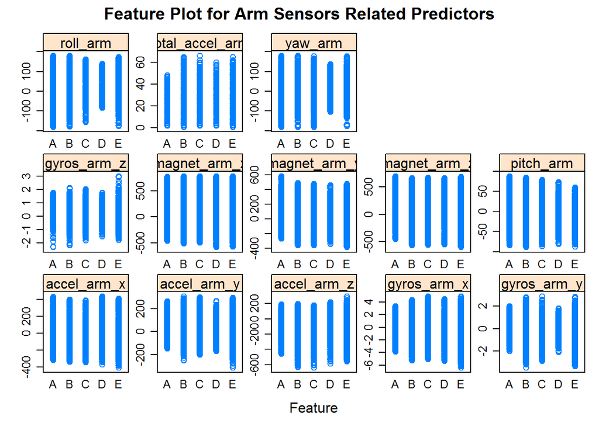

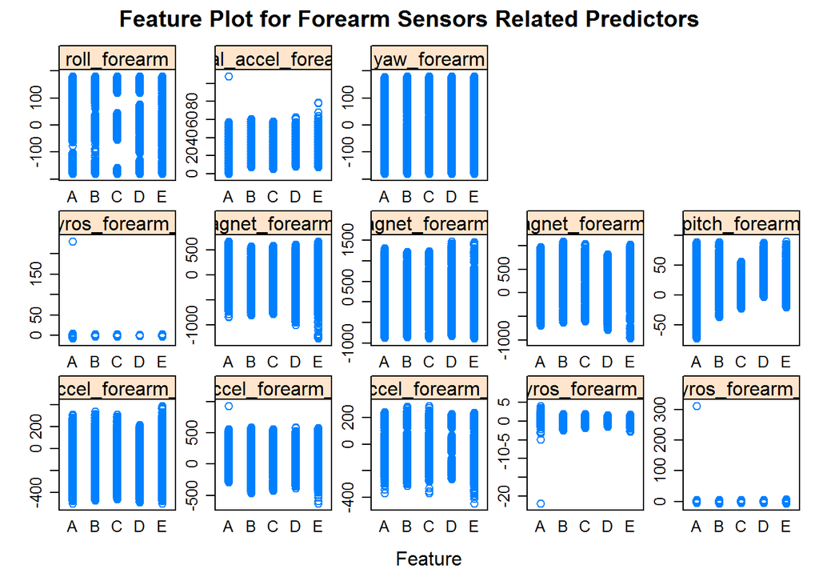

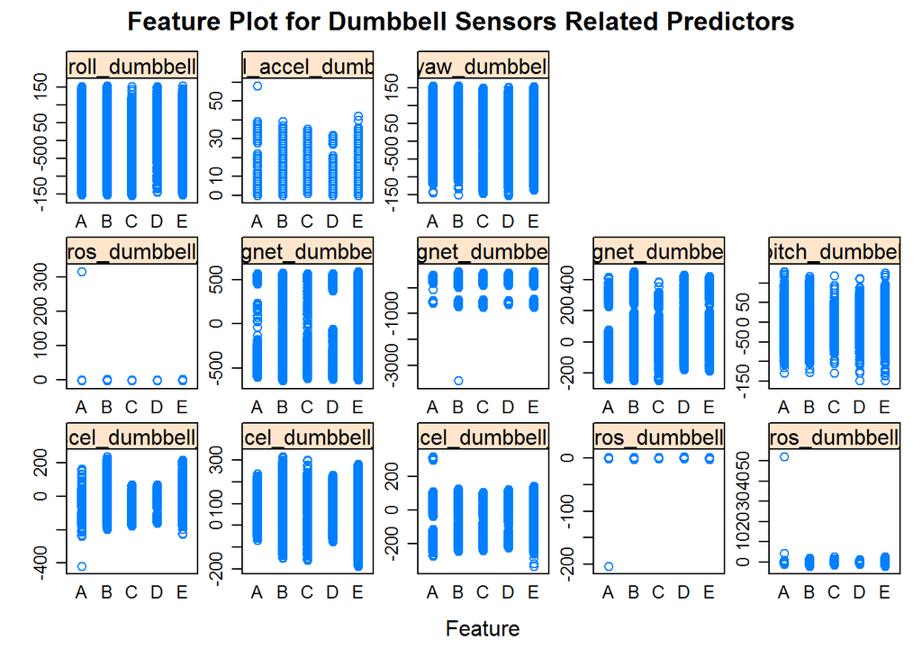

It can be verified from the plots that the behavior of the considered features (or at least the large majority of them) varies as a function of the label, indicating they are potentially good predictors for the model.

Since the number of predictors can still be considered high, one approach could be to employ methods for dimentionality reduction (e.g. PCA) before building the actual models. However, the approach taken here was trying to build models using all predictors first and only if not successful proceed with dimentionality reduction.

Initially a CART model was tried. However, results were not satisfactory. Overall accuracy reached only 0.5008922. Corresponding confusion matrix is presented below:

```
##           Reference
## Prediction    A    B    C    D    E
##          A 1023  331  314  281  106
##          B   17  251   22  115   92
##          C   74  177  348  247  180
##          D    0    0    0    0    0
##          E    2    0    0    0  343
```

Next, Random Forest was employed. Although a long time was taken to train the model (elapsed time was 4052.52 seconds), resulting performance was very good. Overall accuracy reached 0.9951568. Corresponding confusion matrix is presented below:

```
##           Reference
## Prediction    A    B    C    D    E
##          A 1114    2    0    0    0
##          B    2  754    1    0    0
##          C    0    3  680    6    2
##          D    0    0    3  637    0
##          E    0    0    0    0  719
```

Therefore, this model was used to estimate the labels of the test dataset. Corresponding result for each of the twenty cases is presented below:

```
##  [1] B A B A A E D B A A B C B A E E A B B B
## Levels: A B C D E
```

Uploading these results to the course project web page confirmed the good performance of the model: all results were confirmed to be correct.